[figure not shown]

# BIENVENU SEDIN MASSAMBA

**Data scienctist / Geospatial Data Scientist**  
*M.Sc, Geography(Geoinformation & Remote sensing)*

## Analyses de produits et de vente au détail - Analyse exploratoire des données.

Il s'agit d'un ensemble de données transnational qui contient toutes les transactions survenues entre le 01/12/2010 et le 09/12/2011 pour un commerce de détail en ligne non enregistré basé au Royaume-Uni.La société vend principalement des cadeaux uniques en toute occasion. De nombreux clients de l'entreprise sont des grossistes.

#### À propos des données

- Entreprise - Vente au détail en ligne hors magasin basée au Royaume-Uni et enregistrée
- Produits à vendre - Principalement des cadeaux toutes occasions
- Clients - La plupart sont des grossistes (locaux ou internationaux)
- Période des transactions - 1er décembre 2010 - 9 décembre 2011 (un an)

## Resume des resultats obtenus apres l'analyse des donnees

1. Le client **avec le plus grand nombre de commandes vient du Royaume-Uni (UK)**
2. Le client **avec le plus d'argent dépensé pour les achats vient des Pays-Bas**
3. La société reçoit le plus grand nombre de commandes de clients au Royaume-Uni (car il s'agit d'une société basée au Royaume-Uni). Par conséquent, les 5 pays TOP (y compris le Royaume-Uni) qui passent le plus grand nombre de commandes sont les suivants:
   - Royaume-Uni
   - Allemagne
   - France
   - Irlande (EIRE)
   - Spain
4. Comme l'entreprise reçoit le plus grand nombre de commandes de clients au Royaume-Uni (étant donné qu'elle est basée au Royaume-Uni), les clients au Royaume-Uni dépensent le plus pour leurs achats. Par conséquent, les 5 principaux pays (y compris le Royaume-Uni) qui dépensent le plus d'argent pour les achats sont les suivants:
   - Royaume-Uni
   - Pays-Bas
   - Irlande (EIRE)
   - Germany
   - France
5. **Novembre 2011 a le chiffre d'affaires le plus élevé**
   - Le mois avec les ventes les plus faibles est indéterminé car l'ensemble de données se compose de transactions jusqu'au 9 décembre 2011
6. Il y a **aucune transaction le samedi** entre le 1er décembre 2010 et le 9 décembre 2011
7. Le nombre de commandes reçues par l'entreprise a tendance à augmenter du lundi au jeudi et décroît ensuite
8. La société reçoit le plus grand nombre de commandes **à 12:00 pm**
   - Possiblement la plupart des clients ont effectué des achats pendant **lunch hour entre 12:00 pm - 2:00 pm**
9. La société a tendance à **à distribuer des articles GRATUITS pour des achats occasionnels chaque mois (sauf juin 2011)**
   - Cependant, il n'est pas clair quels facteurs contribuent à distribuer les articles GRATUITS aux clients particuliers

```python
# Importation des modules
import pandas as pd
import numpy as np
import matplotlib.pyplot as plt
import seaborn as sns

import warnings
# la version actuelle de seaborn génère un tas d'avertissements que nous ignorerons
warnings.filterwarnings('ignore')
sns.set_style('whitegrid')

#missing data visualization module for Python
import pandas_profiling

import gc
import datetime

%matplotlib inline
# Using ggplot's style
plt.style.use('ggplot')
```

```python
# Chargement de nos données
df = pd.read_csv("data/ecommerce_data.csv", encoding = 'ISO-8859-1')
```

```python
#df['index_col'] = df.index
df.head()
```

|  | InvoiceNo | StockCode | Description | Quantity | InvoiceDate | UnitPrice | CustomerID | Country |
| --- | --- | --- | --- | --- | --- | --- | --- | --- |
| 0 | 536365 | 85123A | WHITE HANGING HEART T-LIGHT HOLDER | 6 | 12/1/2010 8:26 | 2.55 | 17850.0 | United Kingdom |
| 1 | 536365 | 71053 | WHITE METAL LANTERN | 6 | 12/1/2010 8:26 | 3.39 | 17850.0 | United Kingdom |
| 2 | 536365 | 84406B | CREAM CUPID HEARTS COAT HANGER | 8 | 12/1/2010 8:26 | 2.75 | 17850.0 | United Kingdom |
| 3 | 536365 | 84029G | KNITTED UNION FLAG HOT WATER BOTTLE | 6 | 12/1/2010 8:26 | 3.39 | 17850.0 | United Kingdom |
| 4 | 536365 | 84029E | RED WOOLLY HOTTIE WHITE HEART. | 6 | 12/1/2010 8:26 | 3.39 | 17850.0 | United Kingdom |

```python
df.info()
```

```
<class 'pandas.core.frame.DataFrame'>
RangeIndex: 541909 entries, 0 to 541908
Data columns (total 8 columns):
InvoiceNo      541909 non-null object
StockCode      541909 non-null object
Description    540455 non-null object
Quantity       541909 non-null int64
InvoiceDate    541909 non-null object
UnitPrice      541909 non-null float64
CustomerID     406829 non-null float64
Country        541909 non-null object
dtypes: float64(2), int64(1), object(5)
memory usage: 33.1+ MB
```

```python
# vérifier les valeurs manquantes pour chaque colonne
df.isnull().sum().sort_values(ascending=False)
```

```
CustomerID     135080
Description      1454
Country             0
UnitPrice           0
InvoiceDate         0
Quantity            0
StockCode           0
InvoiceNo           0
dtype: int64
```

```python
# vérifier les lignes avec des valeurs manquantes
df[df.isnull().any(axis=1)].head(10)
```

|  | InvoiceNo | StockCode | Description | Quantity | InvoiceDate | UnitPrice | CustomerID | Country |
| --- | --- | --- | --- | --- | --- | --- | --- | --- |
| 622 | 536414 | 22139 | NaN | 56 | 12/1/2010 11:52 | 0.00 | NaN | United Kingdom |
| 1443 | 536544 | 21773 | DECORATIVE ROSE BATHROOM BOTTLE | 1 | 12/1/2010 14:32 | 2.51 | NaN | United Kingdom |
| 1444 | 536544 | 21774 | DECORATIVE CATS BATHROOM BOTTLE | 2 | 12/1/2010 14:32 | 2.51 | NaN | United Kingdom |
| 1445 | 536544 | 21786 | POLKADOT RAIN HAT | 4 | 12/1/2010 14:32 | 0.85 | NaN | United Kingdom |
| 1446 | 536544 | 21787 | RAIN PONCHO RETROSPOT | 2 | 12/1/2010 14:32 | 1.66 | NaN | United Kingdom |
| 1447 | 536544 | 21790 | VINTAGE SNAP CARDS | 9 | 12/1/2010 14:32 | 1.66 | NaN | United Kingdom |
| 1448 | 536544 | 21791 | VINTAGE HEADS AND TAILS CARD GAME | 2 | 12/1/2010 14:32 | 2.51 | NaN | United Kingdom |
| 1449 | 536544 | 21801 | CHRISTMAS TREE DECORATION WITH BELL | 10 | 12/1/2010 14:32 | 0.43 | NaN | United Kingdom |
| 1450 | 536544 | 21802 | CHRISTMAS TREE HEART DECORATION | 9 | 12/1/2010 14:32 | 0.43 | NaN | United Kingdom |
| 1451 | 536544 | 21803 | CHRISTMAS TREE STAR DECORATION | 11 | 12/1/2010 14:32 | 0.43 | NaN | United Kingdom |

```python
# modifier le format de date de facturation - Chaîne au format d'horodatage
df['InvoiceDate'] = pd.to_datetime(df.InvoiceDate, format='%m/%d/%Y %H:%M')
```

```python
df.info()
```

```
<class 'pandas.core.frame.DataFrame'>
RangeIndex: 541909 entries, 0 to 541908
Data columns (total 8 columns):
InvoiceNo      541909 non-null object
StockCode      541909 non-null object
Description    540455 non-null object
Quantity       541909 non-null int64
InvoiceDate    541909 non-null datetime64[ns]
UnitPrice      541909 non-null float64
CustomerID     406829 non-null float64
Country        541909 non-null object
dtypes: datetime64[ns](1), float64(2), int64(1), object(4)
memory usage: 33.1+ MB
```

```python
# df_new sans valeurs manquantes
df_no_missing = df.dropna()
```

```python
# vérifier les valeurs manquantes pour chaque colonne
df_no_missing.isnull().sum().sort_values(ascending=False)
```

```
Country        0
CustomerID     0
UnitPrice      0
InvoiceDate    0
Quantity       0
Description    0
StockCode      0
InvoiceNo      0
dtype: int64
```

```python
# changer le type des colonnes - String en type Int
df_no_missing['CustomerID'] = df_no_missing['CustomerID'].astype('int64')
```

```python
df_no_missing.head()
```

|  | InvoiceNo | StockCode | Description | Quantity | InvoiceDate | UnitPrice | CustomerID | Country |
| --- | --- | --- | --- | --- | --- | --- | --- | --- |
| 0 | 536365 | 85123A | WHITE HANGING HEART T-LIGHT HOLDER | 6 | 2010-12-01 08:26:00 | 2.55 | 17850 | United Kingdom |
| 1 | 536365 | 71053 | WHITE METAL LANTERN | 6 | 2010-12-01 08:26:00 | 3.39 | 17850 | United Kingdom |
| 2 | 536365 | 84406B | CREAM CUPID HEARTS COAT HANGER | 8 | 2010-12-01 08:26:00 | 2.75 | 17850 | United Kingdom |
| 3 | 536365 | 84029G | KNITTED UNION FLAG HOT WATER BOTTLE | 6 | 2010-12-01 08:26:00 | 3.39 | 17850 | United Kingdom |
| 4 | 536365 | 84029E | RED WOOLLY HOTTIE WHITE HEART. | 6 | 2010-12-01 08:26:00 | 3.39 | 17850 | United Kingdom |

```python
# Renommez le dataframe pour rendre le code plus lisible
df2 = df_no_missing.copy()
```

```python
df2.describe().round(2)
```

|  | Quantity | UnitPrice | CustomerID |
| --- | --- | --- | --- |
| count | 406829.00 | 406829.00 | 406829.00 |
| mean | 12.06 | 3.46 | 15287.69 |
| std | 248.69 | 69.32 | 1713.60 |
| min | -80995.00 | 0.00 | 12346.00 |
| 25% | 2.00 | 1.25 | 13953.00 |
| 50% | 5.00 | 1.95 | 15152.00 |
| 75% | 12.00 | 3.75 | 16791.00 |
| max | 80995.00 | 38970.00 | 18287.00 |

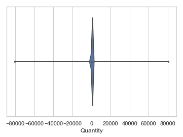

```python
sns.set(style="whitegrid")
ax = sns.violinplot(x=df2["Quantity"])
```

```python
# supprimer les quantités négatives
df2 = df2[df2.Quantity > 0]
df2.describe().round(2)
```

|  | Quantity | UnitPrice | CustomerID |
| --- | --- | --- | --- |
| count | 397924.00 | 397924.00 | 397924.00 |
| mean | 13.02 | 3.12 | 15294.32 |
| std | 180.42 | 22.10 | 1713.17 |
| min | 1.00 | 0.00 | 12346.00 |
| 25% | 2.00 | 1.25 | 13969.00 |
| 50% | 6.00 | 1.95 | 15159.00 |
| 75% | 12.00 | 3.75 | 16795.00 |
| max | 80995.00 | 8142.75 | 18287.00 |

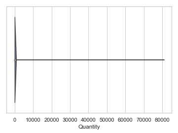

```python
ax = sns.violinplot(x=df2["Quantity"])
```

```python
df2['AmountSpent'] = df2['Quantity'] * df2['UnitPrice']
df2.head()
```

|  | InvoiceNo | StockCode | Description | Quantity | InvoiceDate | UnitPrice | CustomerID | Country | AmountSpent |
| --- | --- | --- | --- | --- | --- | --- | --- | --- | --- |
| 0 | 536365 | 85123A | WHITE HANGING HEART T-LIGHT HOLDER | 6 | 2010-12-01 08:26:00 | 2.55 | 17850 | United Kingdom | 15.30 |
| 1 | 536365 | 71053 | WHITE METAL LANTERN | 6 | 2010-12-01 08:26:00 | 3.39 | 17850 | United Kingdom | 20.34 |
| 2 | 536365 | 84406B | CREAM CUPID HEARTS COAT HANGER | 8 | 2010-12-01 08:26:00 | 2.75 | 17850 | United Kingdom | 22.00 |
| 3 | 536365 | 84029G | KNITTED UNION FLAG HOT WATER BOTTLE | 6 | 2010-12-01 08:26:00 | 3.39 | 17850 | United Kingdom | 20.34 |
| 4 | 536365 | 84029E | RED WOOLLY HOTTIE WHITE HEART. | 6 | 2010-12-01 08:26:00 | 3.39 | 17850 | United Kingdom | 20.34 |

```python
# Ajoutons les colonnes Mois, Jour et Heure que nous utiliserons pour une analyse plus approfondie
# Commençant par le mois de l'année en premier
df2['month_year'] = df2['InvoiceDate'].dt.to_period('M')
df2.head()
```

|  | InvoiceNo | StockCode | Description | Quantity | InvoiceDate | UnitPrice | CustomerID | Country | AmountSpent | month_year |
| --- | --- | --- | --- | --- | --- | --- | --- | --- | --- | --- |
| 0 | 536365 | 85123A | WHITE HANGING HEART T-LIGHT HOLDER | 6 | 2010-12-01 08:26:00 | 2.55 | 17850 | United Kingdom | 15.30 | 2010-12 |
| 1 | 536365 | 71053 | WHITE METAL LANTERN | 6 | 2010-12-01 08:26:00 | 3.39 | 17850 | United Kingdom | 20.34 | 2010-12 |
| 2 | 536365 | 84406B | CREAM CUPID HEARTS COAT HANGER | 8 | 2010-12-01 08:26:00 | 2.75 | 17850 | United Kingdom | 22.00 | 2010-12 |
| 3 | 536365 | 84029G | KNITTED UNION FLAG HOT WATER BOTTLE | 6 | 2010-12-01 08:26:00 | 3.39 | 17850 | United Kingdom | 20.34 | 2010-12 |
| 4 | 536365 | 84029E | RED WOOLLY HOTTIE WHITE HEART. | 6 | 2010-12-01 08:26:00 | 3.39 | 17850 | United Kingdom | 20.34 | 2010-12 |

```python
L = ['year', 'month', 'day', 'dayofweek', 'dayofyear', 'weekofyear', 'quarter']
df2 = df2.join(pd.concat((getattr(df2['InvoiceDate'].dt, i).rename(i) for i in L), axis=1))
df2.head()
```

|  | InvoiceNo | StockCode | Description | Quantity | InvoiceDate | UnitPrice | CustomerID | Country | AmountSpent | month_year | year | month | day | dayofweek | dayofyear | weekofyear | quarter |
| --- | --- | --- | --- | --- | --- | --- | --- | --- | --- | --- | --- | --- | --- | --- | --- | --- | --- |
| 0 | 536365 | 85123A | WHITE HANGING HEART T-LIGHT HOLDER | 6 | 2010-12-01 08:26:00 | 2.55 | 17850 | United Kingdom | 15.30 | 2010-12 | 2010 | 12 | 1 | 2 | 335 | 48 | 4 |
| 1 | 536365 | 71053 | WHITE METAL LANTERN | 6 | 2010-12-01 08:26:00 | 3.39 | 17850 | United Kingdom | 20.34 | 2010-12 | 2010 | 12 | 1 | 2 | 335 | 48 | 4 |
| 2 | 536365 | 84406B | CREAM CUPID HEARTS COAT HANGER | 8 | 2010-12-01 08:26:00 | 2.75 | 17850 | United Kingdom | 22.00 | 2010-12 | 2010 | 12 | 1 | 2 | 335 | 48 | 4 |
| 3 | 536365 | 84029G | KNITTED UNION FLAG HOT WATER BOTTLE | 6 | 2010-12-01 08:26:00 | 3.39 | 17850 | United Kingdom | 20.34 | 2010-12 | 2010 | 12 | 1 | 2 | 335 | 48 | 4 |
| 4 | 536365 | 84029E | RED WOOLLY HOTTIE WHITE HEART. | 6 | 2010-12-01 08:26:00 | 3.39 | 17850 | United Kingdom | 20.34 | 2010-12 | 2010 | 12 | 1 | 2 | 335 | 48 | 4 |

```python
df2.dayofweek.unique()
```

```
array([2, 3, 4, 6, 0, 1], dtype=int64)
```

```python
df2.info()
```

```
<class 'pandas.core.frame.DataFrame'>
Int64Index: 397924 entries, 0 to 541908
Data columns (total 17 columns):
InvoiceNo      397924 non-null object
StockCode      397924 non-null object
Description    397924 non-null object
Quantity       397924 non-null int64
InvoiceDate    397924 non-null datetime64[ns]
UnitPrice      397924 non-null float64
CustomerID     397924 non-null int64
Country        397924 non-null object
AmountSpent    397924 non-null float64
month_year     397924 non-null object
year           397924 non-null int64
month          397924 non-null int64
day            397924 non-null int64
dayofweek      397924 non-null int64
dayofyear      397924 non-null int64
weekofyear     397924 non-null int64
quarter        397924 non-null int64
dtypes: datetime64[ns](1), float64(2), int64(9), object(5)
memory usage: 64.6+ MB
```

```python
# +1 pour faire lundi = 1 ..... jusqu'à dimanche = 7
df2['dayofweek'] = df2['dayofweek'] + 1
df2.head()
```

|  | InvoiceNo | StockCode | Description | Quantity | InvoiceDate | UnitPrice | CustomerID | Country | AmountSpent | month_year | year | month | day | dayofweek | dayofyear | weekofyear | quarter |
| --- | --- | --- | --- | --- | --- | --- | --- | --- | --- | --- | --- | --- | --- | --- | --- | --- | --- |
| 0 | 536365 | 85123A | WHITE HANGING HEART T-LIGHT HOLDER | 6 | 2010-12-01 08:26:00 | 2.55 | 17850 | United Kingdom | 15.30 | 2010-12 | 2010 | 12 | 1 | 3 | 335 | 48 | 4 |
| 1 | 536365 | 71053 | WHITE METAL LANTERN | 6 | 2010-12-01 08:26:00 | 3.39 | 17850 | United Kingdom | 20.34 | 2010-12 | 2010 | 12 | 1 | 3 | 335 | 48 | 4 |
| 2 | 536365 | 84406B | CREAM CUPID HEARTS COAT HANGER | 8 | 2010-12-01 08:26:00 | 2.75 | 17850 | United Kingdom | 22.00 | 2010-12 | 2010 | 12 | 1 | 3 | 335 | 48 | 4 |
| 3 | 536365 | 84029G | KNITTED UNION FLAG HOT WATER BOTTLE | 6 | 2010-12-01 08:26:00 | 3.39 | 17850 | United Kingdom | 20.34 | 2010-12 | 2010 | 12 | 1 | 3 | 335 | 48 | 4 |
| 4 | 536365 | 84029E | RED WOOLLY HOTTIE WHITE HEART. | 6 | 2010-12-01 08:26:00 | 3.39 | 17850 | United Kingdom | 20.34 | 2010-12 | 2010 | 12 | 1 | 3 | 335 | 48 | 4 |

## Exploration et analyse des données

```python
# Consolider le nombre de ventes réalisées par client pour chaque pays
# Nous utilisons le numéro de facture comme décompte des ventes
sales_per_cust = df2.groupby(by=['CustomerID','Country'], as_index=False)['InvoiceNo'].count().sort_values(by='InvoiceNo', ascending=False)
sales_per_cust.columns = ['CustomerID', 'Country', "NumberOfSales"]
sales_per_cust.head(10)
```

|  | CustomerID | Country | NumberOfSales |
| --- | --- | --- | --- |
| 4019 | 17841 | United Kingdom | 7847 |
| 1888 | 14911 | EIRE | 5677 |
| 1298 | 14096 | United Kingdom | 5111 |
| 334 | 12748 | United Kingdom | 4596 |
| 1670 | 14606 | United Kingdom | 2700 |
| 2185 | 15311 | United Kingdom | 2379 |
| 1698 | 14646 | Netherlands | 2080 |
| 570 | 13089 | United Kingdom | 1818 |
| 699 | 13263 | United Kingdom | 1677 |
| 1443 | 14298 | United Kingdom | 1637 |

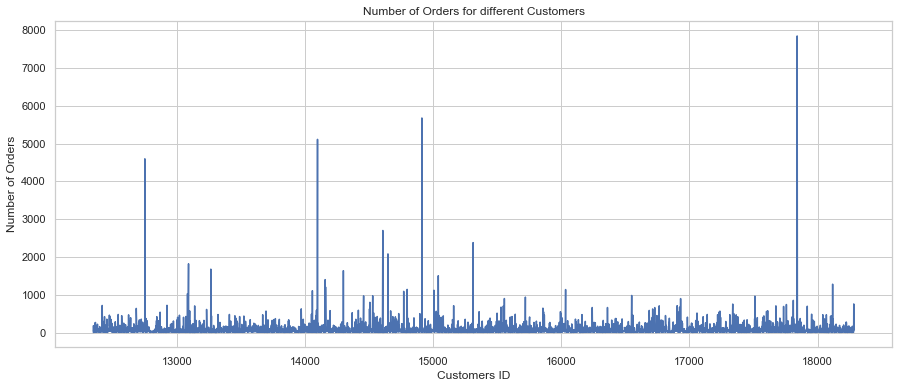

```python
# Visualisation du nombre de ventes pour tous les clients

orders = df2.groupby(by=['CustomerID','Country'], as_index=False)['InvoiceNo'].count()

plt.subplots(figsize=(15,6))
plt.plot(orders.CustomerID, orders.InvoiceNo)
plt.xlabel('Customers ID')
plt.ylabel('Number of Orders')
plt.title('Number of Orders for different Customers')
plt.show()
```

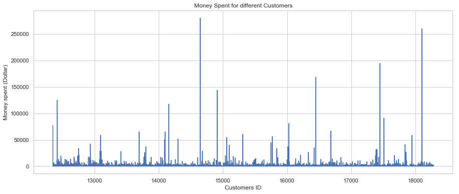

```python
# Visualiser l'argent dépensé pour tous les clients
money_spent = df2.groupby(by=['CustomerID','Country'], as_index=False)['AmountSpent'].sum()

plt.subplots(figsize=(15,6))
plt.plot(money_spent.CustomerID, money_spent.AmountSpent)
plt.xlabel('Customers ID')
plt.ylabel('Money spent (Dollar)')
plt.title('Money Spent for different Customers')
plt.show()
```

```python
# Consolidation du nombre de ventes réalisées par client (chiffre d'affaires)
#nous utilisons use index = False, pour indiquer au groupe que nous ne voulons pas définir l'ID de colonne comme index
spent_per_cust = df2.groupby(by=['CustomerID','Country'], as_index=False)['AmountSpent'].sum().sort_values(by='AmountSpent', ascending=False)
spent_per_cust.columns = ['CustomerID', 'Country', "TotalSpent"]
spent_per_cust.head(10)
```

|  | CustomerID | Country | TotalSpent |
| --- | --- | --- | --- |
| 1698 | 14646 | Netherlands | 280206.02 |
| 4210 | 18102 | United Kingdom | 259657.30 |
| 3737 | 17450 | United Kingdom | 194550.79 |
| 3017 | 16446 | United Kingdom | 168472.50 |
| 1888 | 14911 | EIRE | 143825.06 |
| 57 | 12415 | Australia | 124914.53 |
| 1342 | 14156 | EIRE | 117379.63 |
| 3780 | 17511 | United Kingdom | 91062.38 |
| 2711 | 16029 | United Kingdom | 81024.84 |
| 0 | 12346 | United Kingdom | 77183.60 |